# Understanding Cancer Outcomes: Breast vs. Cervical

### Can we predict survival?

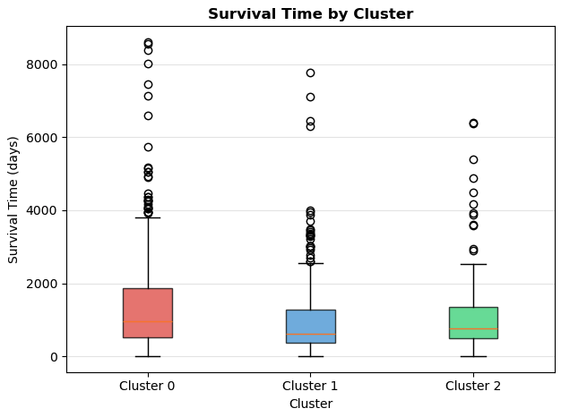

Survival Time by Cluster

Our study used machine learning models to predict how long patients would live based on the clinical information we had. Our best model predicted survival times that were within two years of the actual outcomes. Because the outcomes of these cancers are highly variable, some patients live for many years while others live for much shorter periods of time, the model captures broad patterns but cannot predict precisely at an individual level. There were four important factors for predicting survival: age at diagnosis, cancer stage, number of treatments, and treatment type. Younger patients had better outcomes, earlier cancer stage meant longer survival, more treatments correlated with different outcomes, and specific therapies produced better results. We also investigated whether smoking affected cervical cancer outcomes, but could not draw conclusions about the effects on survival. The majority of our patients reported that they did not smoke.

We combined our data to see if there were any clustering patterns, and our analysis identified three groups of patients: group one had 100% breast cancer patients with a 14.7% mortality rate and an average survival of 3.7 years; group two had 100% breast cancer patients with a 12.3% mortality rate and an average survival of 2.8 years; and group three had cervical cancer patients with a 7.1% mortality rate and an average survival of three years. These cluster groups reflect cancer types, which makes clinical sense, demonstrating that breast and cervical cancer require different approaches and treatments.

# Technical Report

## Model Results

We evaluated three distinct machine learning approaches for predicting cancer patient survival times across both breast cancer (BRCA) and cervical cancer (CESC) datasets:

### Breast Cancer (BRCA) Results

```
======================================================================
                    FINAL MODEL COMPARISON
======================================================================

                     Model          MAE         RMSE            R²
Standard Linear Regression 7.691527e+12 6.158508e+13 -2.406669e+21
  Parametric Curve Fitting 1.288540e+03 1.798930e+03 -1.053500e+00
   Random Forest Regressor 7.924000e+02 1.156060e+03  1.519000e-01

======================================================================
BEST MODEL: Random Forest Regressor
   Achieved lowest MAE of 792.4 days
======================================================================
```

**Best Hyperparameters for Random Forest (BRCA):**

- n_estimators: 300
- max_depth: None
- min_samples_split: 5
- min_samples_leaf: 1
- max_features: 0.3
- bootstrap: True
- Best Cross-Validation MAE: 755.05
- Out-of-Bag Score (R²): 0.1786

### Cervical Cancer (CESC) Results

```
======================================================================
                    FINAL MODEL COMPARISON
======================================================================

                     Model    MAE    RMSE      R²
Standard Linear Regression 960.32 1268.35 -0.8628
  Parametric Curve Fitting 887.97 1285.33 -0.9130
   Random Forest Regressor 730.73  921.17  0.0174

======================================================================
BEST MODEL: Random Forest Regressor
   Achieved lowest MAE of 730.73 days
======================================================================
```

**Best Hyperparameters for Random Forest (CESC):**

- n_estimators: 500
- max_depth: 10
- min_samples_split: 2
- min_samples_leaf: 2
- max_features: log2
- bootstrap: True
- Best Cross-Validation MAE: 709.13
- Out-of-Bag Score (R²): 0.0970

### Model Performance Analysis

**Random Forest consistently emerged as the superior model** for both cancer types, achieving the lowest Mean Absolute Error (MAE) in both cases. This success can be attributed to several key factors:

1. **Non-linear Relationship Capture**: Cancer survival involves complex, non-linear interactions between clinical variables that Random Forest effectively models through its ensemble of decision trees.
2. **Robust Feature Handling**: The algorithm naturally handles mixed data types (categorical staging variables, continuous age/treatment counts) without extensive preprocessing requirements.
3. **Overfitting Resistance**: The ensemble approach and bootstrap sampling provide built-in regularization, preventing overfitting to training data patterns.
4. **Feature Importance**: Random Forest provides interpretable feature importance scores, crucial for clinical applications where understanding driving factors is essential.

The **Standard Linear Regression showed severe overfitting** in the BRCA dataset (extremely high MAE and negative R²), while **Parametric Curve Fitting with Lasso regularization** performed moderately but still struggled with the complex, non-linear nature of cancer survival patterns.

## Discussion

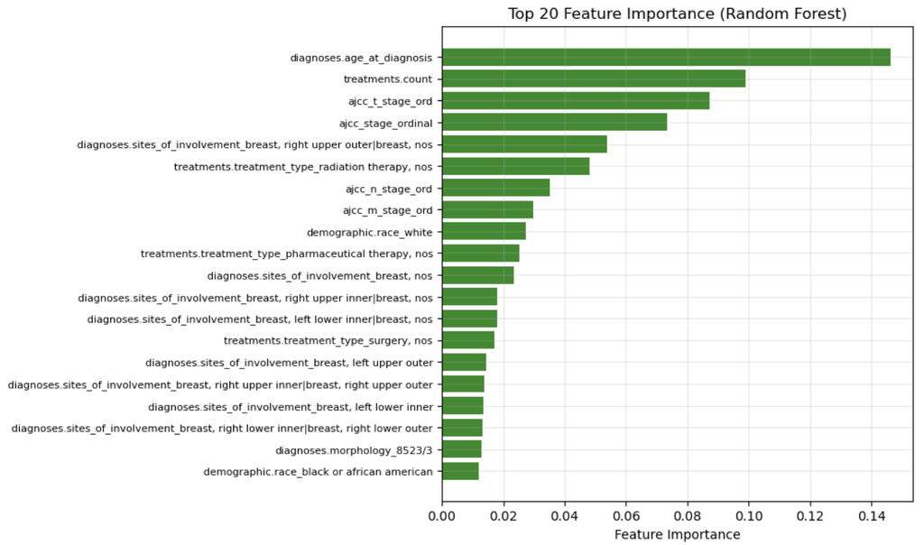

Feature Importance for BRCA Survival Time Prediction

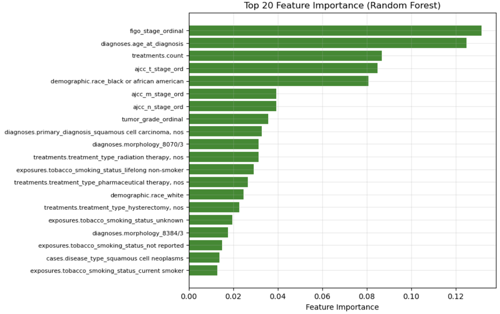

Feature Importance for CESC Survival Time Prediction

These results reinforce why cervical cancer screening is recommended to start earlier at age 21 compared to breast cancer (after 30 for high risk individuals)<sup>1</sup> <sup>2</sup> . However, cervical cancer prevention efforts receive less public visibility than breast cancer campaigns and tying the campaigns together could help catch cervical cancer earlier in the population<sup>3</sup> . This could improve survival time as the tumor stage is the dominant predictor for cervical cancer in our findings and cervical cancer has a lower survival rate of 66% compared to that of breast cancer (90%)<sup>4</sup> .

## Future Improvements

Several technical enhancements could significantly improve our cancer survival prediction models:

### Data Enhancement

- **Multi-modal Integration**: Incorporate genomic data, imaging features, and proteomics to create a more comprehensive patient profile
- **Temporal Modeling**: Include longitudinal treatment response data and biomarker changes over time
- **External Validation**: Test models on independent datasets from different institutions to assess generalizability

### Advanced Modeling Techniques

- **Deep Learning Approaches**: Implement neural networks specifically designed for survival analysis (DeepSurv, DeepHit)
- **Ensemble Methods**: Combine multiple algorithms using stacking or voting approaches for improved robustness
- **Survival-Specific Models**: Utilize Cox Proportional Hazards models or accelerated failure time models designed for time-to-event data

### Feature Engineering

- **Interaction Terms**: Systematically explore clinically meaningful feature interactions (e.g., stage × treatment combinations)
- **Derived Biomarkers**: Create composite scores from multiple clinical variables
- **Time-Varying Covariates**: Model how patient characteristics change during treatment

### Model Optimization

- **Hyperparameter Optimization**: Implement Bayesian optimization or genetic algorithms for more efficient parameter tuning
- **Cross-Validation Strategy**: Use stratified or time-series cross-validation appropriate for clinical data
- **Uncertainty Quantification**: Implement confidence intervals and prediction uncertainty estimates for clinical decision support

### Clinical Integration

- **Interpretability Tools**: Develop SHAP (SHapley Additive exPlanations) or LIME explanations for individual patient predictions
- **Risk Stratification**: Create clinically meaningful risk categories rather than continuous predictions
- **Real-time Deployment**: Build APIs for integration into electronic health record systems

### Evaluation Metrics

- **Clinical Relevance**: Include clinically meaningful metrics like concordance index (C-index) for survival models
- **Subgroup Analysis**: Evaluate model performance across demographic and clinical subgroups to assess fairness
- **Calibration Assessment**: Ensure predicted survival probabilities match observed outcomes across risk levels

## References

1.

Force, U. P. S. T. [Screening for cervical cancer: US preventive services task force recommendation statement](https://doi.org/10.1001/jama.2018.10897). *JAMA* **320**, 674–686 (2018).

2.

Force, U. P. S. T. [Breast cancer: screening](https://doi.org/10.1001/jama.2024.5534). *JAMA* **331**, 749–756 (2024).

3.

Benard, V. B., Thomas, C. C., King, J., *et al.* [Vital signs: Cervical cancer incidence, mortality, and screening — united states, 2007–2012](https://doi.org/10.15585/mmwr.mm6815e1). *MMWR Morbidity and Mortality Weekly Report* **68**, 355–360 (2019).

4.

Siegel, R. L., Miller, K. D., Fuchs, H. E. & Jemal, A. [Cancer statistics, 2023](https://doi.org/10.3322/caac.21763). *CA: A Cancer Journal for Clinicians* **73**, 17–48 (2023).